# Clustering Lab

Heather Chiders

2024-02-29

We’ll start off with some simulated data that has a structure that is amenable to clustering analysis.

```r
#Set the parameters of our simulated data
set.seed(101)

cents <- tibble(
  cluster = factor(1:3),
  num_points = c(100, 150, 50),
  x1 = c(5,0,-3),
  x2 = c(-1,1,-2)
)
```

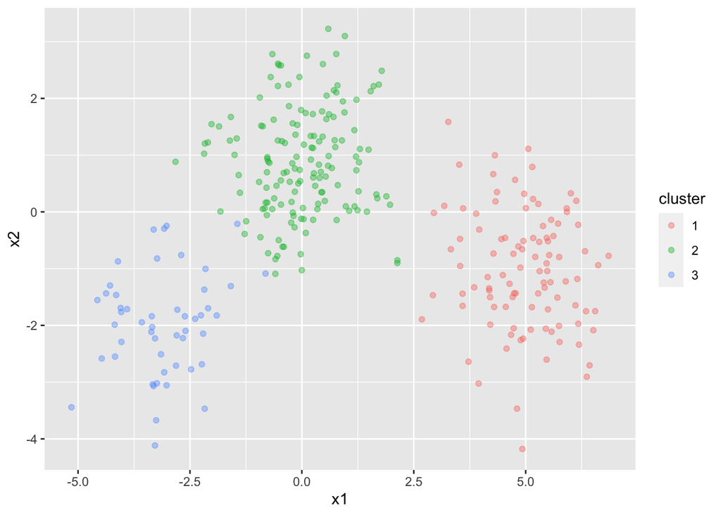

```r
#Simulate the data by passing n and mean to rnorm using map2()
labelled_pts <-
  cents %>%
  mutate(
    x1 = map2(num_points, x1, rnorm),
    x2 = map2(num_points, x2, rnorm)
  ) %>%
  select(-num_points) %>%
           unnest(cols=c(x1,x2))

ggplot(labelled_pts, aes(x1,x2, color=cluster)) +
  geom_point(alpha = 0.4)
```

```r
points <-
  labelled_pts %>%
  select(-cluster)

kclust <- kmeans(points, centers = 3, n = 25)
kclust
```

```
## K-means clustering with 3 clusters of sizes 48, 100, 152
##
## Cluster means:
##             x1         x2
## 1 -3.194015379 -2.0272690
## 2  4.962808900 -1.0254665
## 3 -0.004476705  0.8627456
##
## Clustering vector:
##   [1] 2 2 2 2 2 2 2 2 2 2 2 2 2 2 2 2 2 2 2 2 2 2 2 2 2 2 2 2 2 2 2 2 2 2 2 2 2
##  [38] 2 2 2 2 2 2 2 2 2 2 2 2 2 2 2 2 2 2 2 2 2 2 2 2 2 2 2 2 2 2 2 2 2 2 2 2 2
##  [75] 2 2 2 2 2 2 2 2 2 2 2 2 2 2 2 2 2 2 2 2 2 2 2 2 2 2 3 3 3 3 3 3 3 3 3 3 3
## [112] 3 3 3 3 3 3 3 3 3 3 3 3 3 3 3 3 3 3 3 3 3 3 3 3 3 3 3 3 3 3 3 3 3 3 3 3 3
## [149] 3 3 3 3 3 3 3 3 3 3 3 3 3 3 3 3 3 3 3 3 3 3 3 3 3 3 3 3 3 3 3 3 3 3 3 3 3
## [186] 3 3 3 3 3 3 3 3 3 3 3 3 3 3 3 3 3 3 3 3 3 3 3 3 3 3 3 3 3 3 3 3 3 3 3 3 3
## [223] 3 3 3 3 3 3 3 3 3 3 3 3 3 3 3 3 3 3 3 3 3 3 3 3 3 3 3 3 1 1 1 1 1 1 1 1 1
## [260] 1 1 1 3 1 3 1 1 1 1 1 1 1 1 1 1 1 1 1 1 1 1 1 1 1 1 1 1 1 1 1 1 1 1 1 1 1
## [297] 1 1 1 1
##
## Within cluster sum of squares by cluster:
## [1]  66.89755 195.90406 277.61532
##  (between_SS / total_SS =  84.6 %)
##
## Available components:
##
## [1] "cluster"      "centers"      "totss"        "withinss"     "tot.withinss"
## [6] "betweenss"    "size"         "iter"         "ifault"
```

```r
#now let's try a systematic method for setting k
kclusts <-
  tibble(k=1:9) %>%
  mutate(
    kclust = map(k, ~kmeans(points, .x)),
    augmented = map(kclust, augment, points)
  )
```

```r
#append cluster assignment to tibble
assignments <-
  kclusts %>%
  unnest(cols=c(augmented))
```

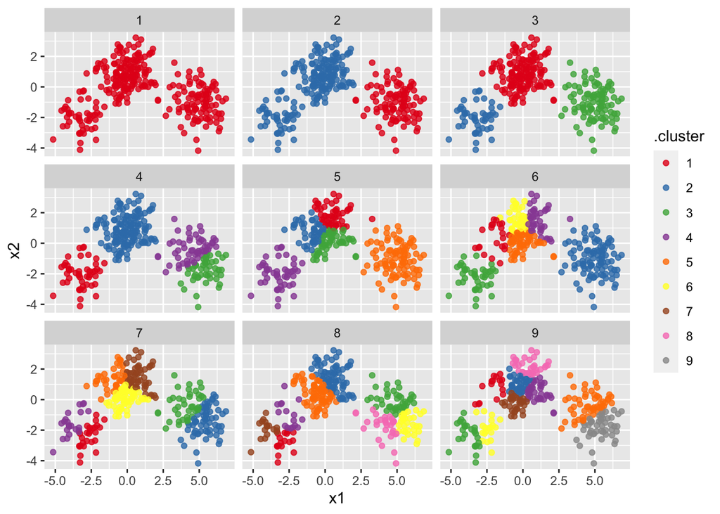

```r
#Plot each model
p1 <-
  ggplot(assignments, aes(x=x1,y=x2)) +
  geom_point(aes(color = .cluster), alpha = 0.8) +
  scale_color_brewer(palette = "Set1") +
  facet_wrap(~k)

p1
```

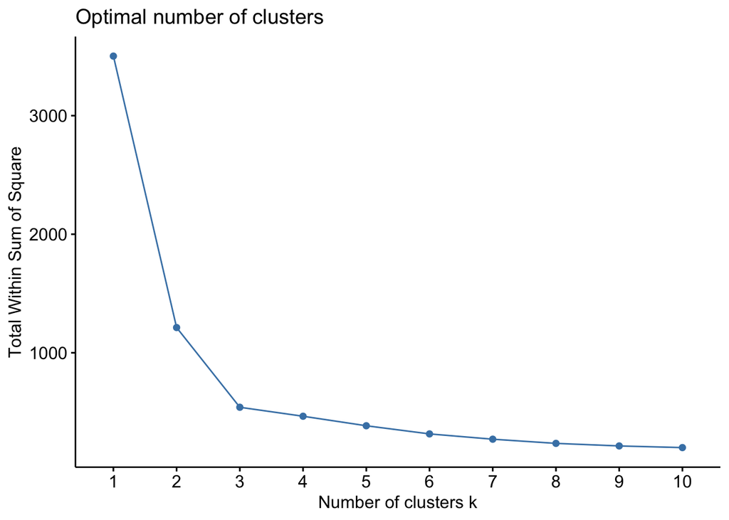

```r
#Use a clustering function from {factoextra} to plot total WSSs
fviz_nbclust(points, kmeans, "wss")
```

```r
#Another plotting method
k3 <- kmeans(points, centers = 3, nstart = 25)
k3
```

```
## K-means clustering with 3 clusters of sizes 48, 100, 152
##
## Cluster means:
##             x1         x2
## 1 -3.194015379 -2.0272690
## 2  4.962808900 -1.0254665
## 3 -0.004476705  0.8627456
##
## Clustering vector:
##   [1] 2 2 2 2 2 2 2 2 2 2 2 2 2 2 2 2 2 2 2 2 2 2 2 2 2 2 2 2 2 2 2 2 2 2 2 2 2
##  [38] 2 2 2 2 2 2 2 2 2 2 2 2 2 2 2 2 2 2 2 2 2 2 2 2 2 2 2 2 2 2 2 2 2 2 2 2 2
##  [75] 2 2 2 2 2 2 2 2 2 2 2 2 2 2 2 2 2 2 2 2 2 2 2 2 2 2 3 3 3 3 3 3 3 3 3 3 3
## [112] 3 3 3 3 3 3 3 3 3 3 3 3 3 3 3 3 3 3 3 3 3 3 3 3 3 3 3 3 3 3 3 3 3 3 3 3 3
## [149] 3 3 3 3 3 3 3 3 3 3 3 3 3 3 3 3 3 3 3 3 3 3 3 3 3 3 3 3 3 3 3 3 3 3 3 3 3
## [186] 3 3 3 3 3 3 3 3 3 3 3 3 3 3 3 3 3 3 3 3 3 3 3 3 3 3 3 3 3 3 3 3 3 3 3 3 3
## [223] 3 3 3 3 3 3 3 3 3 3 3 3 3 3 3 3 3 3 3 3 3 3 3 3 3 3 3 3 1 1 1 1 1 1 1 1 1
## [260] 1 1 1 3 1 3 1 1 1 1 1 1 1 1 1 1 1 1 1 1 1 1 1 1 1 1 1 1 1 1 1 1 1 1 1 1 1
## [297] 1 1 1 1
##
## Within cluster sum of squares by cluster:
## [1]  66.89755 195.90406 277.61532
##  (between_SS / total_SS =  84.6 %)
##
## Available components:
##
## [1] "cluster"      "centers"      "totss"        "withinss"     "tot.withinss"
## [6] "betweenss"    "size"         "iter"         "ifault"
```

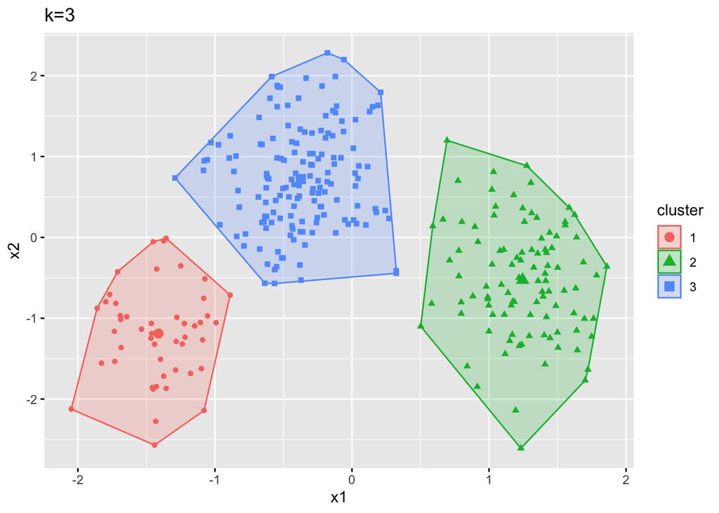

```r
p3 <- fviz_cluster(k3, geom = "point", data = points) +ggtitle("k=3")
p3
```

# In-class assignment!

Now it’s your turn to partition a dataset. For this round we’ll use data from Roberts et al. 2008 on bio-contaminants in Sydney Australia’s Port Jackson Bay. The data are measurements of metal content in two types of co-occurring algae at 10 sample sites around the bay.

```r
#Read in data
metals_dat <- readr::read_csv(here::here("Harbour_metals.csv"))

#Grab pollutant variables
metals_dat2 <- metals_dat[, 4:8]
```

1. Start with k-means clustering - kmeans(). You can start with fviz_nbclust() to identify the best value of k. Then plot the model you obtain with the optimal value of k.

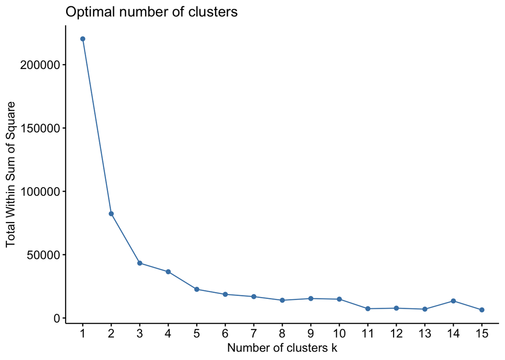

```r
fviz_nbclust(
  metals_dat2,
  kmeans,
  k.max = 15,
  method = "wss")
```

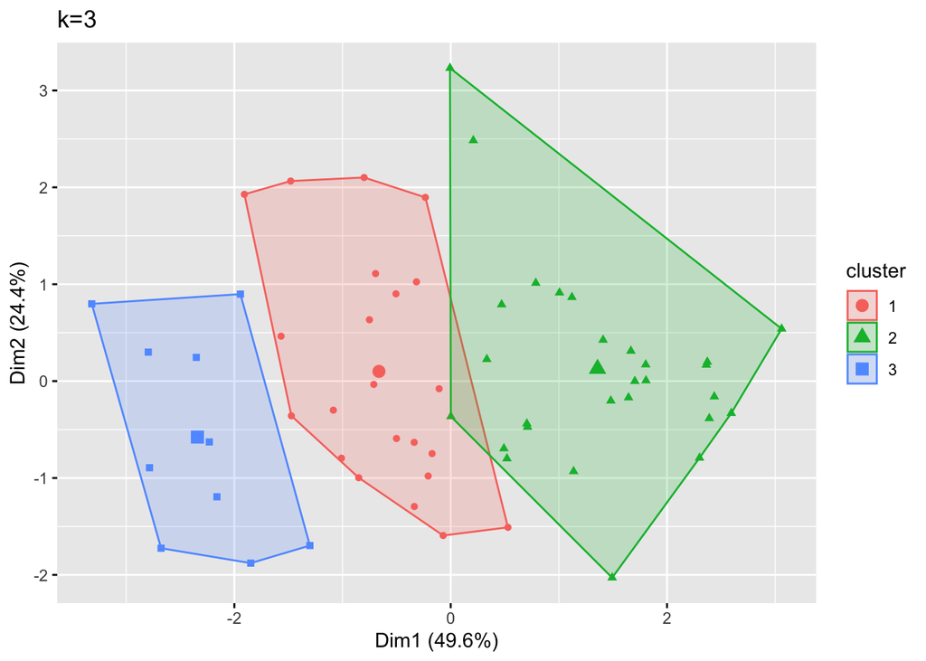

```r
k4 <- kmeans(metals_dat2, centers = 3, nstart = 25)

p4 <- fviz_cluster(k4, geom = "point", data = metals_dat2) +ggtitle("k=3")
p4
```

Do you notice anything different about the spacing between clusters? Why might this be?

Print your model object. Does anything stand out?

80.4% of the variance is occurring between the clusters so roughly 20% of the variance is happening within the cluster. This is pretty good because we want the between cluster variance to be high and the within cluster variance to be low. Its also interesting that there are 2 much larger groups and one smaller group, but it seems like the largest group has the smallest sum of squares by cluster.

```r
k4
```

```
## K-means clustering with 3 clusters of sizes 22, 28, 10
##
## Cluster means:
##         Cd       Cr        Cu        Mn    Ni
## 1 1.076818 6.180455  70.28455  66.79864 2.385
## 2 1.593214 3.462857  22.39893  18.85250 1.870
## 3 0.796000 6.530000 127.09000 126.28200 2.304
##
## Clustering vector:
##  [1] 1 1 3 3 3 3 2 1 1 1 1 1 1 1 3 1 1 3 2 2 2 2 2 2 2 2 1 1 1 1 2 2 2 2 2 2 3 2
## [39] 1 2 1 1 2 2 2 2 2 2 1 3 3 1 3 1 1 2 2 2 2 2
##
## Within cluster sum of squares by cluster:
## [1] 22633.706  7511.094 13159.695
##  (between_SS / total_SS =  80.4 %)
##
## Available components:
##
## [1] "cluster"      "centers"      "totss"        "withinss"     "tot.withinss"
## [6] "betweenss"    "size"         "iter"         "ifault"
```

2. Good, now let’s move to hierarchical clustering that we saw in lecture. The first step for that is to calculate a distance matrix on the data (using dist()). Euclidean is a good choice for the distance method.

```r
# Dissimilarity matrix
d <- dist(metals_dat2, method = "euclidean")
```

2. Use tidy() on the distance matrix so you can see what is going on. What does each row in the resulting table represent?

Each row on the table represents the distance between 2 of the 60 points, so obvervations 1 and 7 are likely not in the same cluster because the distance between them is large.

```r
tidy(d)
```

```
## # A tibble: 1,770 × 3
##    item1 item2 distance
##    <fct> <fct>    <dbl>
##  1 1     2         35.1
##  2 1     3         50.5
##  3 1     4         64.3
##  4 1     5         72.5
##  5 1     6         72.6
##  6 1     7        103.
##  7 1     8         11.4
##  8 1     9         22.4
##  9 1     10        45.1
## 10 1     11        23.3
## # ℹ 1,760 more rows
```

2. Then apply hierarchical clustering with hclust().

```r
hc1 <- hclust(d, method = "complete")
```

2. Now plot the clustering object. You can use something of the form plot(as.dendrogram()). Or you can check out the cool visual options here: https://rpubs.com/gaston/dendrograms

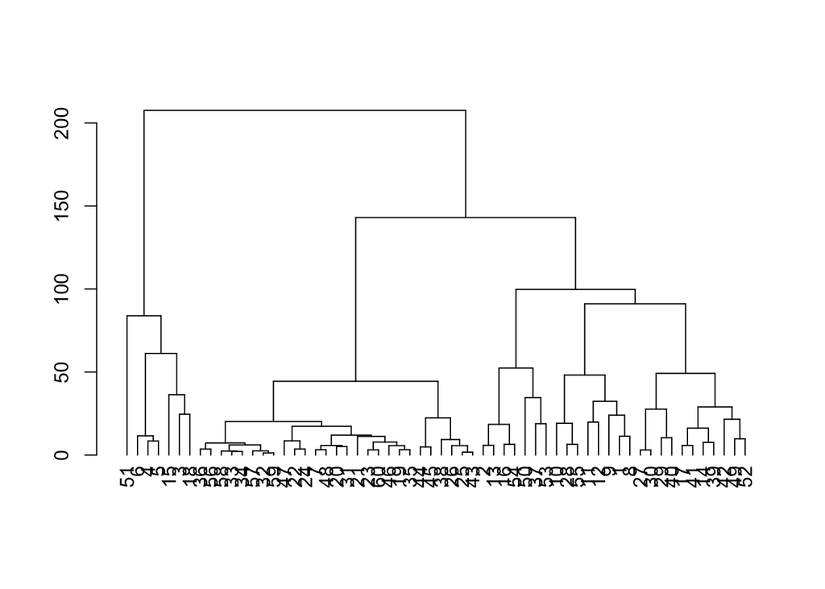

```r
plot(as.dendrogram(hc1))
```

How does the plot look? Do you see any outliers? How can you tell?

It looks like observation 51 is an outlier because it doesn’t have a “nearest” pairing and the length of the branch connecting it to the nearest set of points is very long which means its a far distance away from the other points.

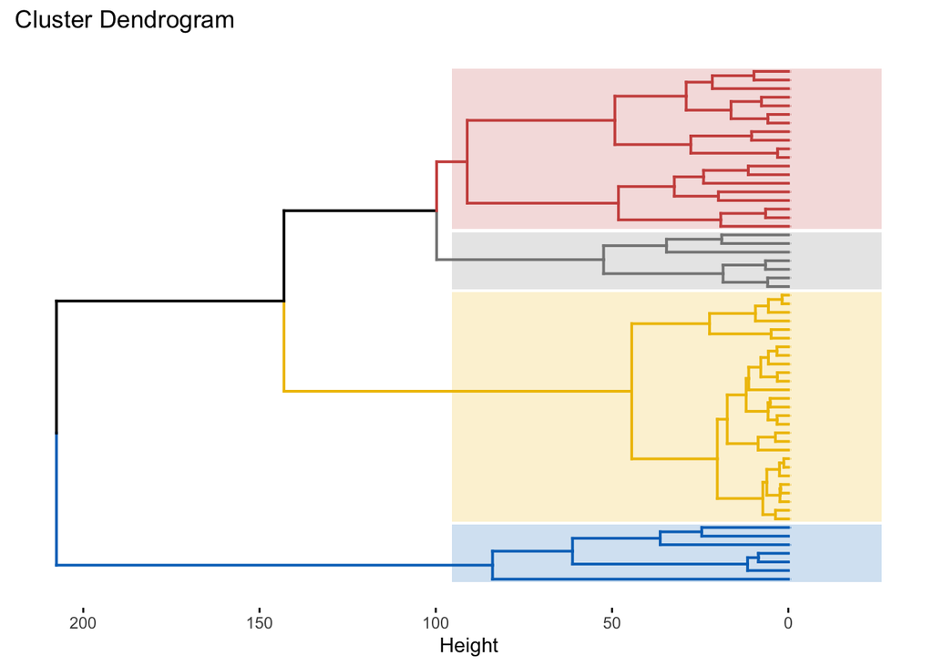

```r
# Plot full dendogram
fviz_dend(
  hc1,
  k = 4,
  horiz = TRUE,
  rect = TRUE,
  rect_fill = TRUE,
  rect_border = "jco",
  k_colors = "jco",
  cex = 0.1
)
```